```python
import pandas as pd
import numpy as np
from scipy import spatial
from scipy.cluster import hierarchy
import random
import matplotlib.pyplot as plt
import seaborn as sns
import math
import nltk
from nltk.stem.wordnet import WordNetLemmatizer
from collections import Counter
from sklearn.feature_extraction.text import TfidfTransformer
#!pip install flair
from flair.data import Sentence, Token
from flair.embeddings import WordEmbeddings
from sklearn.cluster import KMeans, AgglomerativeClustering
from sklearn.metrics import silhouette_score, davies_bouldin_score, calinski_harabasz_score
from sklearn.manifold import TSNE
import warnings
warnings.filterwarnings('ignore')
nltk.download('wordnet')
nltk.download('averaged_perceptron_tagger')
```

```
True
```

# Etap II - inżynieria cech, wstępne modelowanie

## Wczytanie zbioru

Eksplorację robiliśmy na oznaczonym (labelled) zbiorze, teraz wczytujemy ten sam zbiór, jednak chcemy, aby był nieoznaczony, czyli zawierał same słowa, bez informacji o księgach.

```python
data  = pd.read_csv('~/Downloads/AllBooks_baseline_DTM_Labelled.csv')
```

```python
data.head()
```

|  | Unnamed: 0 | foolishness | hath | wholesome | takest | feelings | anger | vaivaswata | matrix | kindled | ... | erred | thinkest | modern | reigned | sparingly | visual | thoughts | illumines | attire | explains |
| --- | --- | --- | --- | --- | --- | --- | --- | --- | --- | --- | --- | --- | --- | --- | --- | --- | --- | --- | --- | --- | --- |
| 0 | Buddhism_Ch1 | 0 | 0 | 0 | 0 | 0 | 0 | 0 | 0 | 0 | ... | 0 | 0 | 0 | 0 | 0 | 0 | 0 | 0 | 0 | 0 |
| 1 | Buddhism_Ch2 | 0 | 0 | 0 | 0 | 0 | 0 | 0 | 0 | 0 | ... | 0 | 0 | 0 | 0 | 0 | 0 | 0 | 0 | 0 | 0 |
| 2 | Buddhism_Ch3 | 0 | 0 | 0 | 0 | 0 | 0 | 0 | 0 | 0 | ... | 0 | 0 | 0 | 0 | 0 | 0 | 0 | 0 | 0 | 0 |
| 3 | Buddhism_Ch4 | 0 | 0 | 0 | 0 | 0 | 0 | 0 | 0 | 0 | ... | 0 | 0 | 0 | 0 | 0 | 0 | 0 | 0 | 0 | 0 |
| 4 | Buddhism_Ch5 | 0 | 0 | 0 | 0 | 0 | 0 | 0 | 0 | 0 | ... | 0 | 0 | 0 | 0 | 0 | 0 | 0 | 0 | 0 | 0 |

5 rows × 8267 columns

Zaczynamy jazdę bez trzymanki, tzn. usuwamy kolumnę etykiet w zbiorze.

```python
data = data.drop('Unnamed: 0', axis = 1)
```

```python
data.shape # sprawdzamy ponownie wymiar, aby przypomnieć go sobie
```

```
(590, 8266)
```

Mamy 8266 słów i 590 wierszy oznaczających ich krotność występowania w danym rodziale jakiejś księgi (chociaż nie wiemy teraz jakiej). Przypominając, nie mamy też kolumn całkowicie pustych, gdyż zbiór wykorzystuje jedynie te, które wystąpują przynajmniej raz.

## Co zamierzamy zrobić w tej części projektu?

1. Lematyzacja (zmniejszenie liczby kolumn o 2234 słowa)
2. Przygotowanie ramek danych, które będą już gotowe do trenowania modelu klasteryzującego. Przewidujemy kilka sposobów:
- skorzystanie z narzędzia TfidfTransformer na ramce danych zawierającej liczności poszczególnych słów - bez używania embeddingu
- skorzystanie z embeddingu GloVe na dwa sposoby:
  - korzystając z możliwości dodawania wektorów reprezentujących słowa spróbujemy obliczyć średnią ważoną z wektorów dla każdego rozdziału, gdzie wagami będą znormalizowane liczby występowania poszczególnych słów
  - poprzez wybranie kilku najbardziej popularnych słów w księdze (pomoże nam brak stopwords) i skonkatenowania wektorów ich reprezentujących.
1. Wstępne modelowanie - próba wykorzystania podstawowych modeli klasteryzacji i przetestowania naszych utworzonych na różne sposoby ramek danych w celu znalezienia optymalnej liczby klastrów.

## Lematyzacja

Jednym z podejść jakie chcemy zastosować to lematyzacja słów. Zmniejszymy w ten sposób liczbę kolumn w naszych danych.

```python
def lemmatization(data):
    '''
    Podajemy numpy array list a zwracana jest numpy array list słów po lematyzacji
    '''
    lem = WordNetLemmatizer()
    A = []
    for i in data.tolist():
        a = lem.lemmatize(i)
        a = lem.lemmatize(a, 'a')
        a = lem.lemmatize(a, 'v')
        A.append(a)
    return np.array(A)
```

```python
def dimension_reduction(data, columns_original, columns_lem):
    '''
    Funkcja przyjmuje dwie listy kolumn, gdzie druga jest po lematyzacji.
    Zwraca zmniejszoną ramkę danych o powtarzające się słowa,
    a z tych co się powtarzały sumuje ich liczności do jednej takiej kolumny
    '''
    if len(columns_original) != len(columns_lem):
        raise ValueError(f'Błąd! Należy podać listy tej samej długości. Podane listy są długości {len(columns_original)} oraz {len(columns_lem)}')

    tmp_df = pd.DataFrame()
    for word in np.unique(columns_lem):
        word_indices = np.where(columns_lem == word)[0]
        new_vector = data.iloc[:, word_indices].sum(axis = 1)
        tmp_df[word] = new_vector
    return tmp_df
```

```python
words_list = np.array(data.columns)
words_after_lem = lemmatization(words_list)
```

```python
data_small = dimension_reduction(data, words_list, words_after_lem)
data_small.shape
```

```
(590, 6032)
```

Nasza ramka zmniejszyła się o ponad 2000 kolumn, zgodnie z założeniem.

## I sposób przygotowania danych - TfidfTransformer

Informacja: Przy strojeniu parametrów będzie należało użyć Pipeline z TfidTransformerem jako jednym z etapów.

```python
tfidf = TfidfTransformer()
df_tfidf = tfidf.fit_transform(data_small) #Zwraca np.ndarray
print(df_tfidf)
```

[output not shown]

# GloVe

Stwórzmy ramkę danych, w której kolumny będą kolejnymi wektorami reprezentującymi słowa.

```python
glove_embedding = WordEmbeddings('glove')
```

```python
def create_embedding_df(data):
    '''
    Na podstawie ramki danych, gdzie nazwy kolumn są poszczególnymi wyrazami,
    zwracana jest ramka danych, gdzie kolumny to wektory reprezentujące wyrazy
    '''
    emb_df = pd.DataFrame()
    for word in data.columns:
        emb_df[word] = glove_embedding.get_cached_vec(word)
    return emb_df
```

```python
emb_df = create_embedding_df(data_small)
emb_df.head()
```

|  | FALSE | TRUE | a | aaron | abandon | abase | abasement | abash | abate | abateth | ... | yet | yield | yieldeth | yoga | yoke | young | youth | youthful | zeal | zorobabel |
| --- | --- | --- | --- | --- | --- | --- | --- | --- | --- | --- | --- | --- | --- | --- | --- | --- | --- | --- | --- | --- | --- |
| 0 | 0.53588 | 0.154640 | -0.270860 | 0.763110 | 0.435610 | 0.0 | -0.220970 | 0.0 | -0.023343 | 0.0 | ... | -0.11941 | 0.03682 | 0.0 | 0.549180 | -0.43826 | 0.27828 | 0.78928 | 0.023712 | 0.26712 | 0.0 |
| 1 | -0.64758 | 0.345230 | 0.044006 | 0.258170 | -0.150330 | 0.0 | -0.426290 | 0.0 | -0.632030 | 0.0 | ... | 0.54188 | 0.41745 | 0.0 | 0.154480 | -0.23806 | 0.49947 | 0.62846 | 0.367300 | 0.22467 | 0.0 |
| 2 | 0.37271 | 0.765160 | -0.020260 | 0.085101 | -0.040623 | 0.0 | 0.056718 | 0.0 | -0.685440 | 0.0 | ... | 0.62174 | 0.57371 | 0.0 | -0.683010 | 0.21823 | 0.24943 | -0.46468 | 0.728840 | -0.31812 | 0.0 |
| 3 | -0.39776 | -0.067509 | -0.173950 | -0.733850 | 0.366380 | 0.0 | 0.118040 | 0.0 | -0.314010 | 0.0 | ... | -0.10935 | 1.43230 | 0.0 | 0.914770 | -0.91236 | -0.68331 | -0.48076 | -0.350470 | -0.40172 | 0.0 |
| 4 | 0.33143 | -0.227520 | 0.644400 | -0.148130 | -0.922810 | 0.0 | 0.017697 | 0.0 | -0.902500 | 0.0 | ... | -0.15776 | -0.58973 | 0.0 | -0.045836 | -0.55755 | -0.24754 | 0.16992 | 0.029986 | -0.11042 | 0.0 |

5 rows × 6032 columns

Możemy dostrzeć, że niektóre kolumny są wypełnione 0. wynika to z tego, że niektórych słów baza GloVe nie posiada. Zobaczmy przykładowe słowa:

```python
random.seed(6754)
lacking_words = emb_df.columns[emb_df.sum() == 0].tolist()
print(f"Kilka spośród {len(lacking_words)} ({round(100*len(lacking_words)/len(emb_df.columns), 2)}%) słów, których nie ma w GloVe: \n{random.sample(lacking_words, 12)}")
```

```
Kilka spośród 899 (14.9%) słów, których nie ma w GloVe:
['selfseeking', 'curseth', 'extinguisheth', 'nosecontact', 'welltrained', 'birthbirth', 'snowcrystal', 'direful', 'oilofthejoints', 'selfknowledge', 'foreshewed', 'prayest']
```

## Graficzna reprezentacja działania GloVe

Dzięki reprezentacji wielowymiarowych wektorów na jednej płaszczyźnie, jesteśmy w stanie zobrazować wektory reprezentujące słowa jako punkty na przestrzeni kartezjańskiej. Na drugiej ilustracji prezentowane jest skupisko słów związanych ze zwierzętami.

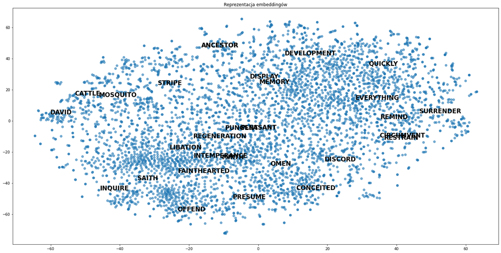

```python
word_vectors = {word: emb_df[word].tolist() for word in emb_df.columns if np.absolute(emb_df[word]).sum()>0}
tsne = TSNE(random_state=47)
Y = tsne.fit_transform(list(word_vectors.values()))

plt.figure(figsize = (24, 12))
plt.scatter(Y[:, 0], Y[:, 1], alpha = 0.6)
ind = random.choices(range(len(word_vectors)), k=30)
for label, x, y in zip(np.array(list(word_vectors.keys()))[ind], Y[ind, 0], Y[ind, 1]):
    plt.annotate(label.upper(), xy=(x, y), xytext=(4, 0), textcoords="offset points", weight = 'bold', size = 17)
plt.title('Reprezentacja embeddingów')
plt.show()
```

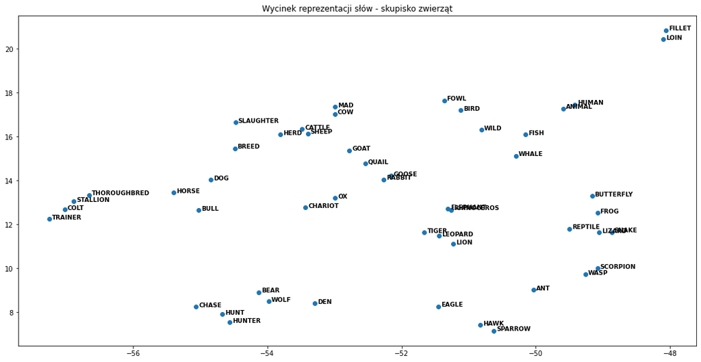

```python
plt.figure(figsize=(18, 9))
ind = (Y[:,0] < -48) & (Y[:,0] > -58) & (Y[:,1] <22) & (Y[:,1] > 7)
plt.scatter(Y[ind,0], Y[ind,1])
for label, x, y in zip(np.array(list(word_vectors.keys()))[ind], Y[ind, 0], Y[ind, 1]):
    plt.annotate(label.upper(), xy=(x, y), xytext=(4, 0), textcoords="offset points", weight = 'bold', size = 9)
plt.title('Wycinek reprezentacji słów - skupisko zwierząt')
plt.show()
```

### Co zrobić z nieistniejącymi słowami w GloVe?

Można się w tym momencie zastanowić co zrobić z wyrazami zakończonymi na -eth (które są najpewniej czasownikami w 3. os. l.p. - archaizmy, [źródło](https://www.dictionary.com/browse/-eth)), -est (archaizmy oznaczające czasowniki w 2 os. l.p. [źródło](https://www.yourdictionary.com/prayest); choć pamiętajmy, że to też końcówka superlatywów) oraz wyrazów niejako złożonych z wielu. Pamiętajmy, że dla tak zmienionej ramki, trzeba by ponownie rozpocząć od lematyzacji (co nie byłoby jakimś dużym problemem).

```python
emb_df.head()
```

|  | FALSE | TRUE | a | aaron | abandon | abase | abasement | abash | abate | abateth | ... | yet | yield | yieldeth | yoga | yoke | young | youth | youthful | zeal | zorobabel |
| --- | --- | --- | --- | --- | --- | --- | --- | --- | --- | --- | --- | --- | --- | --- | --- | --- | --- | --- | --- | --- | --- |
| 0 | 0.53588 | 0.154640 | -0.270860 | 0.763110 | 0.435610 | 0.0 | -0.220970 | 0.0 | -0.023343 | 0.0 | ... | -0.11941 | 0.03682 | 0.0 | 0.549180 | -0.43826 | 0.27828 | 0.78928 | 0.023712 | 0.26712 | 0.0 |
| 1 | -0.64758 | 0.345230 | 0.044006 | 0.258170 | -0.150330 | 0.0 | -0.426290 | 0.0 | -0.632030 | 0.0 | ... | 0.54188 | 0.41745 | 0.0 | 0.154480 | -0.23806 | 0.49947 | 0.62846 | 0.367300 | 0.22467 | 0.0 |
| 2 | 0.37271 | 0.765160 | -0.020260 | 0.085101 | -0.040623 | 0.0 | 0.056718 | 0.0 | -0.685440 | 0.0 | ... | 0.62174 | 0.57371 | 0.0 | -0.683010 | 0.21823 | 0.24943 | -0.46468 | 0.728840 | -0.31812 | 0.0 |
| 3 | -0.39776 | -0.067509 | -0.173950 | -0.733850 | 0.366380 | 0.0 | 0.118040 | 0.0 | -0.314010 | 0.0 | ... | -0.10935 | 1.43230 | 0.0 | 0.914770 | -0.91236 | -0.68331 | -0.48076 | -0.350470 | -0.40172 | 0.0 |
| 4 | 0.33143 | -0.227520 | 0.644400 | -0.148130 | -0.922810 | 0.0 | 0.017697 | 0.0 | -0.902500 | 0.0 | ... | -0.15776 | -0.58973 | 0.0 | -0.045836 | -0.55755 | -0.24754 | 0.16992 | 0.029986 | -0.11042 | 0.0 |

5 rows × 6032 columns

Sprawdźmy ile słów niewystępujących w glove pojawia się tylko w jednym wierszu (rozdziale księgi).

```python
unique_words = data_small==data_small.sum()
unique_words = data_small.columns[unique_words.any()]
```

```python
words = [item for item in lacking_words if item in set(unique_words)]
len(words)
```

```
613
```

Z 899 aż 613 słów występuje tylko w jednym rozdziale z wymienionych ksiąg religijnych.

Możemy spróbować usunąć słowa, których glove nie zna i zobaczyć, jaki to wpływ ma na wyniki klasteryzacji. Innym sposobem jest zastąpienie tych słów bezokolicznikami albo innymi odpowiednimi.

```python
# ramka z usuniętymi lacking_words
data_remove_lacking = data_small.drop(columns=lacking_words)
```

Powyżej widzimy zastosowanie pierwszego ze sposobów. Po przyjrzeniu się danym (tym 899 słowom), okazuje się, że zmiana ich formy byłaby utrudniona. Chcąc usunąć automatycznie 'eth' ze wszystkich wyrazów, kończących się na to, pojawiły się problemy spowodowane ze względu na oboczności, np. do -> doeth, die -> dieth, study -> studieth. Ponadto po usunięciu kolumn z tymi słowami, okazuje się, że łączna suma kolumn, które usunęliśmy stanowi ok. 3% sumy wszystkich słów (co wynika też z tego, że w większości są to słowa unikatowe dla wiersza).

## II sposób przygotowania danych - z wykorzystaniem GloVe - wyznaczanie średniego wektora dla każdego rozdziału

Wróćmy do naszego sposobu tworzenia danych. Mamy wektory opisujące poszczególne słowa, teraz pora je wykorzystać do określania wierszy w naszej ramce danych.

```python
def create_avg_df(data, emb_df = emb_df, len_vector = 100):
    '''
    Funkcja przyjmuje dane, normalizuje je wierszami tak,
    by suma wartości w wierszu była równa 1 i oblicza ważoną średnią z wektorów reprezentujących wyrazy.
    '''
    other = pd.Series(np.where(data.sum(axis = 1) == 0, 1, data.sum(axis = 1))) #obsluga sytuacji gdy suma wiersza = 0
    normalized_data = data.div(other, axis = 0)
    normalized_matrix = normalized_data.to_numpy()
    x = pd.DataFrame(index = range(normalized_data.shape[0]), columns = range(len_vector))
    emb_matrix = emb_df.to_numpy()
    for i in range(normalized_data.shape[0]):
        try:
            av_vector = (emb_matrix*normalized_matrix[i]).sum(axis = 1)
            x.iloc[i,:]= av_vector
        except:
            print(i, norm_counts, av_vector)
            break
    return x
```

```python
# tworzymy ramkę z usuniętymi unikatowymi słowami, których nie ma w glove
# (normalizacja jest wewnatrz funkcji, wiec wektory maja odpowiednie wartosci)
df_glove_remove_1 = create_avg_df(data_remove_lacking, emb_df.drop(columns=lacking_words))
df_glove_remove_1.head(14) # 590 wierszow - rozdzialow i dla kazdego 100 elementowy wektor
```

|  | 0 | 1 | 2 | 3 | 4 | 5 | 6 | 7 | 8 | 9 | ... | 90 | 91 | 92 | 93 | 94 | 95 | 96 | 97 | 98 | 99 |
| --- | --- | --- | --- | --- | --- | --- | --- | --- | --- | --- | --- | --- | --- | --- | --- | --- | --- | --- | --- | --- | --- |
| 0 | 0.0148224 | 0.0532324 | 0.142631 | -0.104899 | -0.274871 | 0.353607 | -0.311695 | 0.0731739 | 0.049139 | -0.0585611 | ... | -0.205693 | -0.208003 | -0.0309949 | 0.222448 | 0.0529626 | 0.0727431 | 0.00883021 | -0.471047 | 0.133694 | 0.0660905 |
| 1 | -0.112149 | 0.190064 | -0.00307962 | 0.107538 | -0.0911491 | 0.248867 | -0.184562 | -0.0851074 | -0.0995522 | -0.0580483 | ... | -0.214138 | -0.136388 | -0.0593079 | 0.0945748 | -0.219996 | -0.216785 | -0.0955696 | -0.311163 | 0.284629 | 0.26535 |
| 2 | -0.130623 | 0.149028 | 0.096406 | 0.0191876 | -0.468234 | 0.132414 | -0.286704 | -0.0740274 | -0.0804246 | -0.0533583 | ... | -0.253477 | -0.119138 | -0.0695976 | 0.196204 | -0.094991 | 0.0363648 | 0.0569906 | -0.383268 | 0.364541 | 0.200272 |
| 3 | 0.0871999 | 0.124726 | 0.128619 | 0.136666 | -0.179197 | 0.0777405 | -0.221026 | -0.0983191 | 0.0444256 | 0.000183049 | ... | -0.245747 | -0.12013 | -0.11605 | 0.263287 | -0.163256 | -0.0699615 | -0.150738 | -0.413882 | 0.212808 | 0.216401 |
| 4 | -0.156064 | 0.279174 | 0.0843226 | -0.0053292 | -0.017511 | 0.149469 | 0.0354536 | 0.118564 | -0.141131 | 0.0101112 | ... | -0.16533 | -0.124707 | -0.102416 | 0.195022 | -0.0955474 | -0.027789 | -0.0811785 | -0.312029 | 0.313445 | -0.0610292 |
| 5 | -0.0230435 | 0.20123 | 0.210369 | -0.0775213 | -0.333914 | 0.324092 | -0.305027 | -0.0233712 | 0.0374888 | -0.150721 | ... | -0.130358 | 0.00727954 | 0.0649767 | 0.121655 | -0.156287 | 0.0740607 | 0.0391068 | -0.375109 | 0.255689 | 0.00551864 |
| 6 | -0.178463 | 0.187237 | 0.329912 | 0.0231524 | -0.106672 | 0.173034 | -0.254443 | -0.00795594 | 0.0358069 | 0.043251 | ... | -0.0626312 | 0.0153622 | -0.199159 | 0.0889603 | -0.197752 | -0.0487688 | -0.218658 | -0.434897 | 0.462785 | 0.209753 |
| 7 | -0.0590829 | 0.329002 | 0.2433 | 0.15475 | -0.120932 | 0.22011 | -0.181227 | -0.0596673 | 0.0649064 | -0.00121893 | ... | -0.0775824 | -0.330502 | -0.0698625 | 0.144626 | -0.207893 | -0.139359 | -0.157894 | -0.505169 | 0.359535 | 0.0272162 |
| 8 | -0.183501 | 0.292573 | 0.308969 | -0.0700523 | -0.391024 | 0.258314 | -0.242708 | -0.11253 | 0.17954 | -0.107478 | ... | -0.0390006 | -0.108268 | -0.038717 | -0.159222 | -0.0125532 | -0.116041 | -0.183118 | -0.361027 | 0.276925 | 0.199974 |
| 9 | -0.117803 | 0.266229 | 0.356082 | 0.143213 | -0.231806 | 0.236895 | -0.180579 | -0.206767 | 0.317603 | -0.00624948 | ... | -0.0587862 | 0.0172369 | -0.202213 | -0.266861 | -0.0857761 | -0.0875026 | -0.117955 | -0.404239 | 0.120866 | 0.282382 |
| 10 | -0.145791 | 0.161645 | 0.213726 | -0.0894679 | -0.0854416 | 0.169941 | -0.208391 | 0.101112 | 0.224484 | -0.0177331 | ... | -0.0502973 | -0.23717 | -0.0151773 | 0.0778016 | -0.186083 | 0.0499101 | -0.0681695 | -0.354275 | 0.443986 | -0.05202 |
| 11 | -0.126387 | 0.291509 | 0.234872 | -0.148521 | -0.511389 | 0.234218 | -0.295121 | 0.274418 | 0.192699 | -0.222819 | ... | -0.0463803 | -0.0827922 | 0.121448 | -0.0195155 | -0.212625 | 0.17758 | -0.120484 | -0.39685 | 0.140142 | 0.241052 |
| 12 | 0.0407723 | 0.124734 | 0.1866 | 0.0764925 | -0.0561419 | -0.0517341 | 0.0266497 | 0.0712679 | 0.190062 | 0.407019 | ... | -0.249893 | 0.0392545 | -0.0313824 | 0.122551 | -0.00283099 | -0.00503781 | -0.35279 | -0.55657 | 0.464962 | 0.206472 |
| 13 | 0 | 0 | 0 | 0 | 0 | 0 | 0 | 0 | 0 | 0 | ... | 0 | 0 | 0 | 0 | 0 | 0 | 0 | 0 | 0 | 0 |

14 rows × 100 columns

## III sposób przygotowania danych - z wykorzystaniem GloVe - konkatenacja wektorów

Trzeci sposób to wybranie kilku najbardziej popularnych słów w rozdziale i skonkatenowanie wektorów ich reprezentujących.

```python
warnings.filterwarnings('default')
def create_concat_df(data, best_words, emb_df = emb_df, len_vector=100):
    """
    data - dane,
    best_words - liczba najpopularniejszych słów, które będą brane pod uwagę,
    emb_df - ramka gdzie kolumny to wektor danego słowa
    len_vector - dlugosc embedding wektora.
    Funkcja zwraca ramke danych, w ktorej ksiegi sa prezentowane za pomoca
    wektora o dlugosci (best_words*len_vector)
    """
    out = pd.DataFrame(index = range(data.shape[0]), columns = range(len_vector*best_words))
    for i in range(data.shape[0]):
        words_indices = data.iloc[i,:].argsort()[-best_words:]
        word_list = data.columns[words_indices].tolist()
        word_list.reverse()
        vec_list = [0]*(100*best_words)
        if best_words > (data.iloc[i,:]).sum():
            warnings.warn(f"Liczba wybranych najczęstszych słów\njest większa od liczby dostępnych słów w rozdziale o indeksie {i}. "+
            f"Liczba wybranych: {best_words}, liczba dostępnych: {(data.iloc[i,:]).sum()}")
        for j in range(len(word_list)):
            if data.loc[i, word_list[j]] == 0: #Gdy ktores z kolei slowo nie wystepuje w ksiedze, to zostawiamy 0 i przerywamy petle, bo nastepne tez nie sytapia.
            # Zera beda rowniez gdy slowo nie wystepuje w emb_df
                break
            vec_list[(j*100):(j*100+100)] = emb_df[word_list[j]].tolist()
        out.iloc[i,:] = vec_list
    return out
```

```python
# ramka dla usuniętych unikatowych słów
df_glove_remove_2 = create_concat_df(data_remove_lacking, 3, emb_df.drop(columns=lacking_words))
df_glove_remove_2
```

|  | 0 | 1 | 2 | 3 | 4 | 5 | 6 | 7 | 8 | 9 | ... | 290 | 291 | 292 | 293 | 294 | 295 | 296 | 297 | 298 | 299 |
| --- | --- | --- | --- | --- | --- | --- | --- | --- | --- | --- | --- | --- | --- | --- | --- | --- | --- | --- | --- | --- | --- |
| 0 | 0.24027 | -0.729 | 0.25767 | -0.73294 | 0.11195 | 0.4878 | -0.89241 | 0.34992 | 0.04753 | -0.4576 | ... | -0.24344 | 0.028006 | -0.20553 | 0.34779 | 0.26696 | -0.072483 | 0.040601 | -0.76416 | -0.84741 | 0.45093 |
| 1 | -0.79252 | 0.1112 | -0.15714 | 0.33814 | -1.5105 | -0.2456 | -1.0716 | -0.35966 | -0.62459 | 0.21511 | ... | -0.74472 | 0.068495 | -0.96137 | 0.80156 | -0.19509 | -0.59453 | 0.34407 | 0.4502 | 0.60143 | 0.52268 |
| 2 | -0.79252 | 0.1112 | -0.15714 | 0.33814 | -1.5105 | -0.2456 | -1.0716 | -0.35966 | -0.62459 | 0.21511 | ... | 0.031764 | -0.13444 | 0.29704 | -0.25073 | -0.69218 | 0.021038 | -0.3006 | -0.33461 | 0.044349 | 0.57541 |
| 3 | 0.64998 | 0.65044 | 0.85794 | -0.15231 | -0.30682 | 0.30113 | -0.48529 | -0.082432 | 0.58796 | -0.5256 | ... | -0.65577 | -0.2405 | 0.12842 | 0.33902 | 0.81716 | 0.31335 | 0.62835 | -1.1465 | 0.6587 | 0.12363 |
| 4 | -0.068609 | 0.37234 | 0.008263 | -0.29759 | 0.50497 | 0.3553 | 0.39532 | 0.80128 | -0.92972 | 0.037341 | ... | -0.36196 | -0.51768 | -0.56312 | 0.715 | 0.30657 | -0.33092 | -0.078182 | -0.97847 | 0.70058 | -0.16847 |
| ... | ... | ... | ... | ... | ... | ... | ... | ... | ... | ... | ... | ... | ... | ... | ... | ... | ... | ... | ... | ... | ... |
| 585 | 0.23302 | 0.38258 | 0.89732 | -0.60346 | -0.68923 | 0.22225 | 0.15507 | -0.18096 | 0.62266 | -0.36591 | ... | 0.49042 | -0.45365 | 0.81719 | 0.15014 | -0.31772 | 0.031711 | 0.069947 | -0.7478 | 0.13684 | 0.18927 |
| 586 | 0.35203 | 0.72574 | 0.66062 | -0.59452 | -0.62715 | 0.68504 | -1.4714 | -0.35226 | 0.28189 | 0.45762 | ... | -0.36848 | -0.02252 | -0.12575 | 0.028982 | -0.08836 | -0.81304 | -0.089856 | 0.15016 | -0.71826 | 0.23967 |
| 587 | 0.12343 | 0.23462 | 0.46594 | -0.50448 | -0.47754 | 0.56953 | -1.4267 | -0.89084 | 0.74374 | -0.37632 | ... | 0.62199 | -0.30939 | 0.19955 | 0.61977 | -1.2068 | 0.24397 | -0.11748 | 0.57281 | 0.60816 | 0.27485 |
| 588 | 0.35203 | 0.72574 | 0.66062 | -0.59452 | -0.62715 | 0.68504 | -1.4714 | -0.35226 | 0.28189 | 0.45762 | ... | 0.085689 | 0.13295 | -0.1807 | -0.11854 | -0.82985 | 0.13784 | -0.34359 | -0.45744 | 0.49646 | 0.34906 |
| 589 | 0.35203 | 0.72574 | 0.66062 | -0.59452 | -0.62715 | 0.68504 | -1.4714 | -0.35226 | 0.28189 | 0.45762 | ... | 0.43407 | -0.62837 | -0.98157 | 0.0042248 | -0.39847 | 0.21771 | -0.88988 | -0.17269 | 0.67932 | 0.34972 |

590 rows × 300 columns

## Wstępne modelowanie - szukanie optymalnej liczby klastrów

Na początek zaczniemy od znalezienia optymalnej liczby klastrów dla przygotowanych na trzy sposoby danych, wykorzystując domyślne parametry i metodę kombinatoryczą - K-średnich oraz metodę hierarchiczną - aglomeracyjną.

Miary, które pomogą nam wybrać to:

- metoda łokcia
- metoda Silhouette
- indeks Daviesa-Bouldina
- indeks Calińskiego-Harabasza

Zdefiniujmy następujące funkcje pomocnicze:

```python
def elbow_plot(data, k_max=20, model=KMeans, title='Metoda łokcia dla KMeans', color = 'b'):
    '''
    Funkcja wyświetla wykres dla metody łokcia i danego modelu
    '''
    wcss=[]
    for i in range (2, k_max+1):
        Model=model(n_clusters=i)
        Model.fit(data)
        wcss.append(Model.score(data)*(-1))
    x=range(2,k_max+1)
    plt.figure(figsize=(15,8))
    plt.plot(x, wcss, 'h-' + color, label = 'Elbow method')
    plt.xticks(np.arange(min(x), max(x)+1, 2))
    plt.title(title)
    plt.legend()
    plt.show()
```

```python
def score_plot(data, k_max=20, model=KMeans, score=silhouette_score,  title='Score dla różnej liczby klastrów', color = 'b'):
    '''
    Fukncja wyświetla wykres dla danego score i modelu,
    oraz listę klastrów posortowaną względem score malejąco
    '''
    scores = []
    for i in range(2, k_max+1):
        Model = model(n_clusters=i)
        predictions = Model.fit_predict(data)
        if score==silhouette_score:
            scores.append(score(data, predictions, metric='euclidean'))
        else:
            scores.append(score(data,predictions))
    x=range(2,k_max+1)
    plt.figure(figsize=(15,8))
    plt.plot(x, scores, 'h-'+color, label = score.__name__)
    plt.xticks(np.arange(min(x), max(x)+1, 2))
    plt.xlabel('Number of clusters')
    plt.ylabel('Score')
    plt.legend()
    plt.title(title)
    plt.show()
    ranking = np.argsort(scores)[::-1]+2 #liczba klastrów posortowana malejąco względem score
    return ranking
```

### Algorytm K-średnich

#### df_tfidf - ramka po zastosowaniu TfidfTransformer

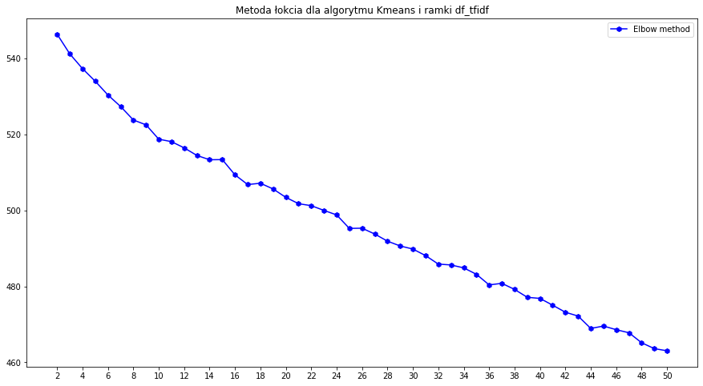

```python
elbow_plot(df_tfidf, 50, KMeans, "Metoda łokcia dla algorytmu Kmeans i ramki df_tfidf")
```

Możemy się przyjrzeć, że metoda łokcia niewiele nam mówi o tym czego szukamy - nie widać specjalnie żadnego przegięcia.

Może lepiej przyjrzeć się lepiej zdefiniowanym miarom, które nie są tak subiektywne.

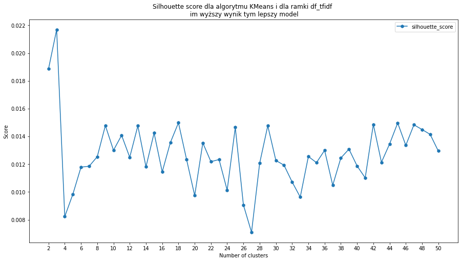

```python
silhouette_ranking_tfidf = score_plot(df_tfidf, 50, KMeans, silhouette_score,
                                      "Silhouette score dla algorytmu KMeans i dla ramki df_tfidf \n im wyższy wynik tym lepszy model")
```

UWAGA: Poniższe wywołania na normalnej macierzy nie działają - trzeba zrobić `df.tfidf.todense()`.

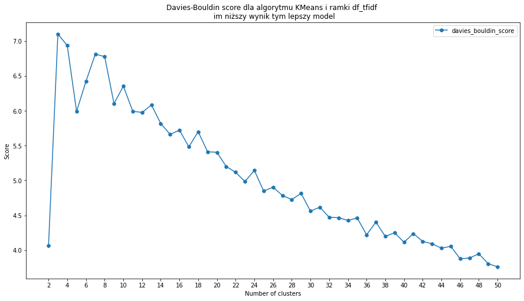

```python
db_ranking_tfidf = score_plot(df_tfidf.todense(), 50, KMeans, davies_bouldin_score,
                              "Davies-Bouldin score dla algorytmu KMeans i ramki df_tfidf \n im niższy wynik tym lepszy model")
```

Ciekawe jest to, iż wynik się wydaje się odmienny niż poprzednio, jako że w Silhouette 3 jest najlepszą liczbą a dla indeksu DB najgorszą.

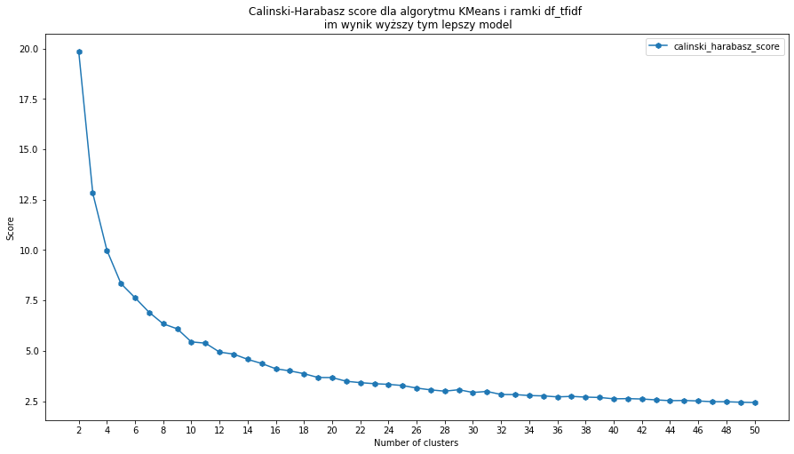

```python
ch_ranking_tfidf = score_plot(df_tfidf.todense(), 50, KMeans, calinski_harabasz_score,
                              "Calinski-Harabasz score dla algorytmu KMeans i ramki df_tfidf \n im wynik wyższy tym lepszy model")
```

#### df_glove_remove_1 - I sposób z GloVe

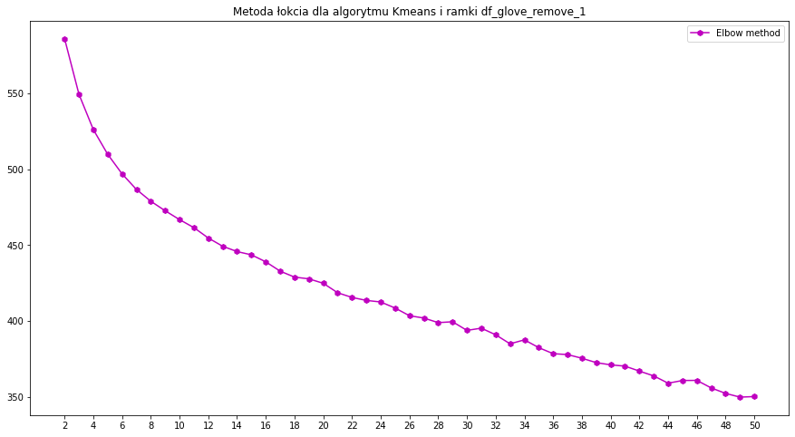

```python
elbow_plot(df_glove_remove_1, 50, KMeans, "Metoda łokcia dla algorytmu Kmeans i ramki df_glove_remove_1", color = 'm')
```

W przypadku tej ramki, widać bardzo delikatne przegięcie z samym początku (2,3,4 klastry?), jednak nie jest to takie przegięcie, które określałoby wybór odpowiedniej liczby skupisk. Ponownie metoda łokcia się nie sprawdziła.

Przejdźmy do metryk lepiej interpretowalnych:

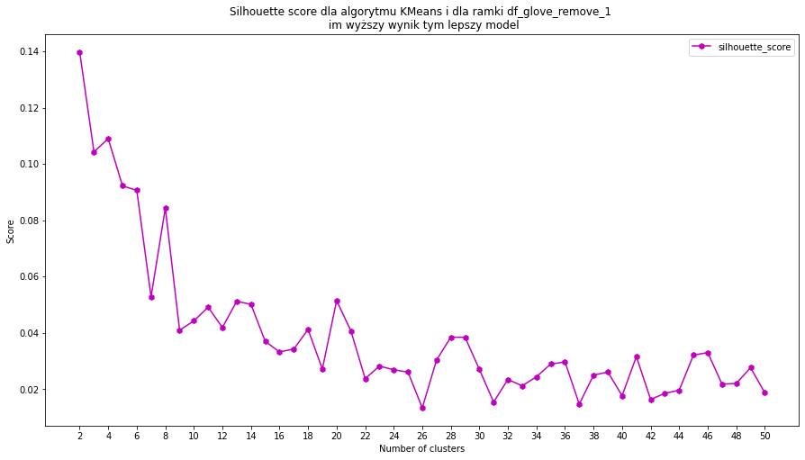

```python
silhouette_ranking_glove1 = score_plot(df_glove_remove_1, 50, KMeans, silhouette_score,
                                       "Silhouette score dla algorytmu KMeans i dla ramki df_glove_remove_1 \n im wyższy wynik tym lepszy model", color = 'm')
```

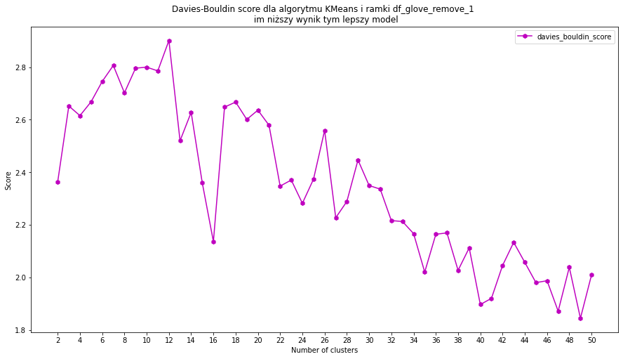

```python
db_ranking_glove1 = score_plot(df_glove_remove_1, 50, KMeans, davies_bouldin_score,
                               "Davies-Bouldin score dla algorytmu KMeans i ramki df_glove_remove_1 \n im niższy wynik tym lepszy model", color = 'm')
```

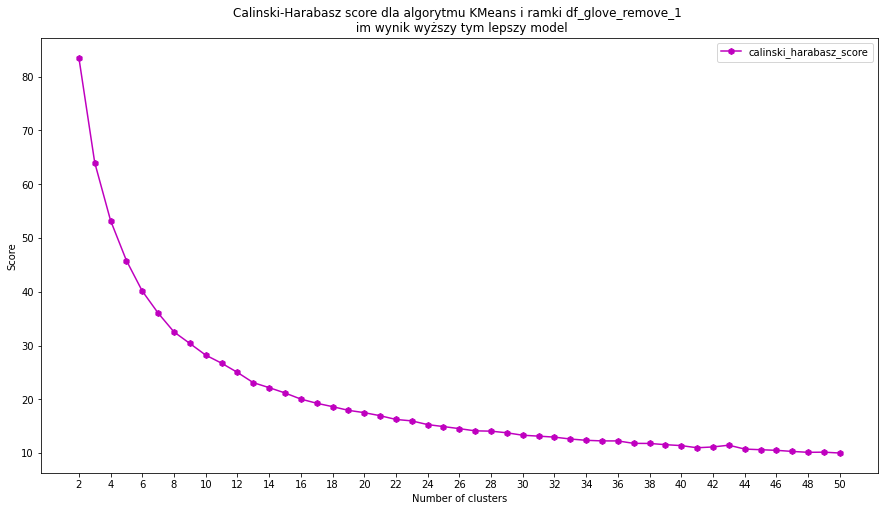

```python
ch_ranking_glove1 = score_plot(df_glove_remove_1, 50, KMeans, calinski_harabasz_score,
                               "Calinski-Harabasz score dla algorytmu KMeans i ramki df_glove_remove_1 \n im wynik wyższy tym lepszy model", color = 'm')
```

#### df_glove_remove_2 - II sposób z GloVe

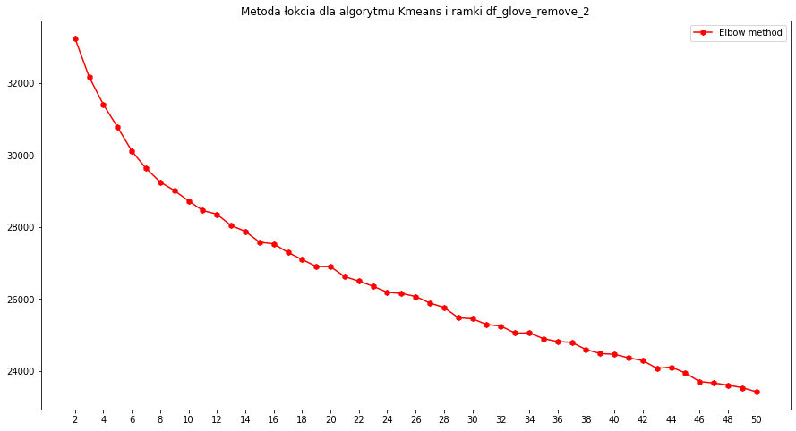

```python
elbow_plot(df_glove_remove_2, 50, KMeans, "Metoda łokcia dla algorytmu Kmeans i ramki df_glove_remove_2", color = 'r')
```

Ponownie brak specjalnego przegięcia na tym zakresie. Metoda łokcia zdaje się nie sprawdzać na naszych ramkach danych.

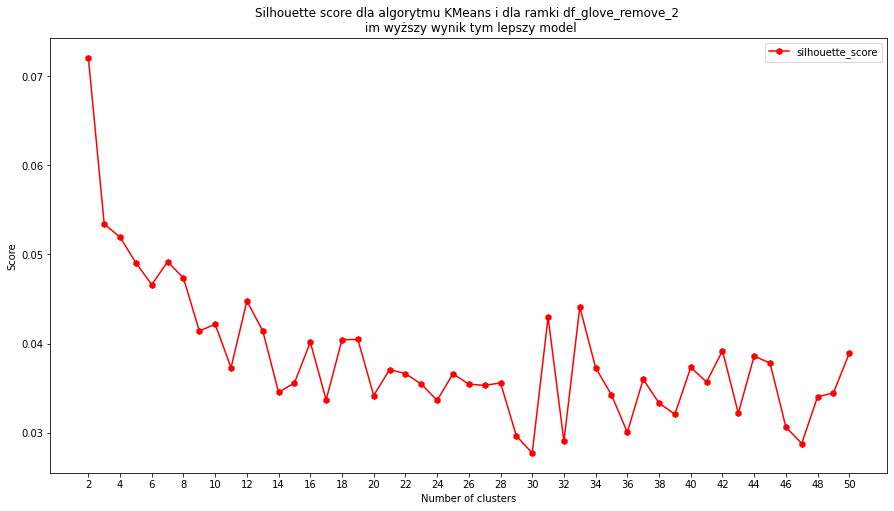

```python
silhouette_ranking_glove2 = score_plot(df_glove_remove_2, 50, KMeans, silhouette_score,
                                       "Silhouette score dla algorytmu KMeans i dla ramki df_glove_remove_2 \n im wyższy wynik tym lepszy model", color = 'r')
```

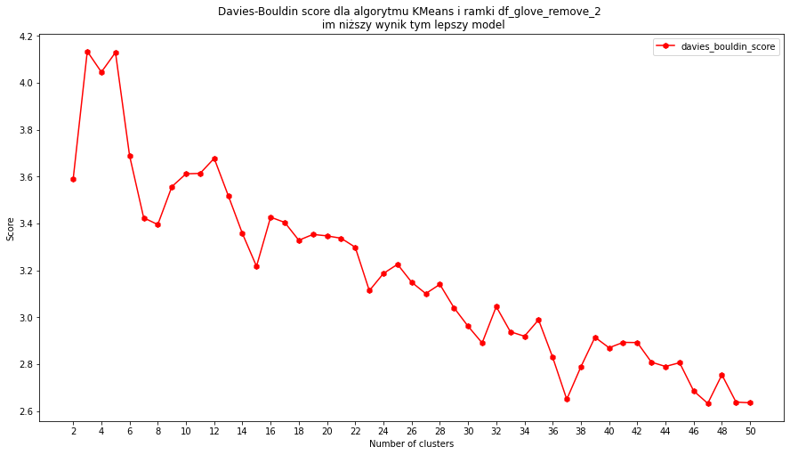

```python
db_ranking_glove2 = score_plot(df_glove_remove_2, 50, KMeans, davies_bouldin_score,
                               "Davies-Bouldin score dla algorytmu KMeans i ramki df_glove_remove_2 \n im niższy wynik tym lepszy model", color = 'r')
```

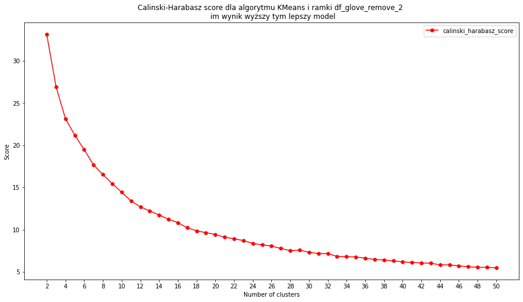

```python
ch_ranking_glove2 = score_plot(df_glove_remove_2, 50, KMeans, calinski_harabasz_score,
                               "Calinski-Harabasz score dla algorytmu KMeans i ramki df_glove_remove_2 \n im wynik wyższy tym lepszy model", color = 'r')
```

Wygląda na to, że i w pierwszej jak i drugiej ramce glove dla algorytmu k-średnich najlepszy jest podział na dwa klastry. Będzie można porównywać to z ośmioma skupiskami (liczba ksiąg) albo powyciągać inne, które mają w miarę wysokie wyniki.

Może ten podział na dwa ma jakiś sens? Religie Bliskiego i Dalekiego Wschodu?

### Agglomerative clustering

Sprawdźmy to samo na innym algorytmie - agglomerative clustering.

#### df_tfidf - ramka po zastosowaniu TfidfTransformer

AgglomerativeClustering nie przyjmuje jako argumentu macierzy rzadkiej. W takiej formie mamy df_tfidf dlatego trzeba na niej wywołać funkcję todense().

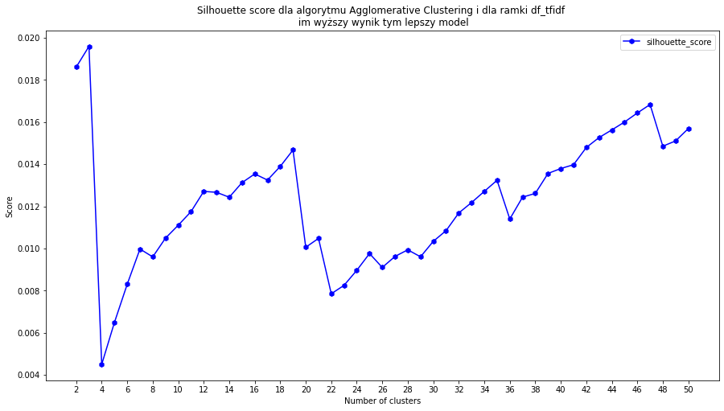

```python
silhouette_ranking_tfidf_agg = score_plot(df_tfidf.todense(), 50, AgglomerativeClustering, silhouette_score,"Silhouette score dla algorytmu Agglomerative Clustering i dla ramki df_tfidf \n im wyższy wynik tym lepszy model")
```

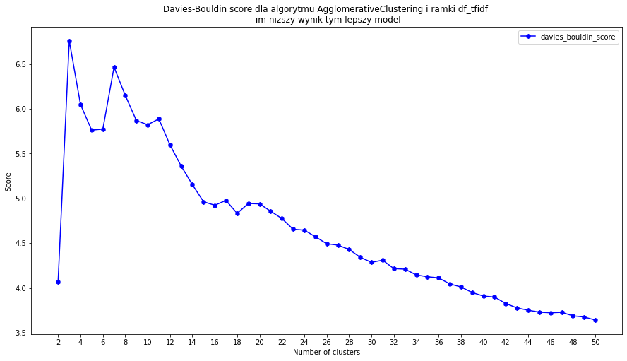

```python
db_ranking_tfidf_agg = score_plot(df_tfidf.todense(), 50, AgglomerativeClustering, davies_bouldin_score, "Davies-Bouldin score dla algorytmu AgglomerativeClustering i ramki df_tfidf \n im niższy wynik tym lepszy model")
```

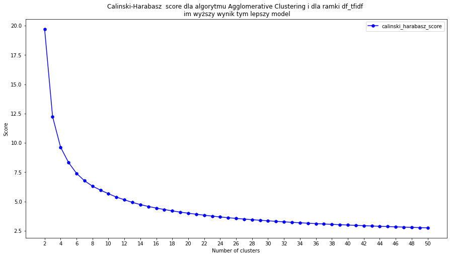

```python
ch_ranking_tfidf_agg = score_plot(df_tfidf.todense(), 50, AgglomerativeClustering, calinski_harabasz_score,"Calinski-Harabasz  score dla algorytmu Agglomerative Clustering i dla ramki df_tfidf \n im wyższy wynik tym lepszy model")
```

#### df_glove_remove_1 - I sposób z GloVe

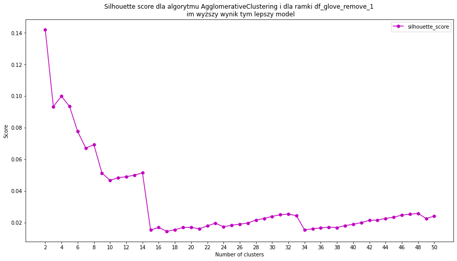

```python
silhouette_ranking_glove1_agg = score_plot(df_glove_remove_1, 50, AgglomerativeClustering, silhouette_score, "Silhouette score dla algorytmu AgglomerativeClustering i dla ramki df_glove_remove_1 \n im wyższy wynik tym lepszy model", color = 'm')
```

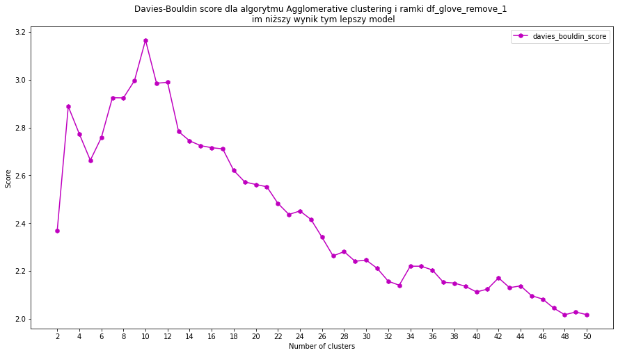

```python
db_ranking_glove1_agg = score_plot(df_glove_remove_1, 50, AgglomerativeClustering, davies_bouldin_score, "Davies-Bouldin score dla algorytmu Agglomerative clustering i ramki df_glove_remove_1 \n im niższy wynik tym lepszy model", color = 'm')
```

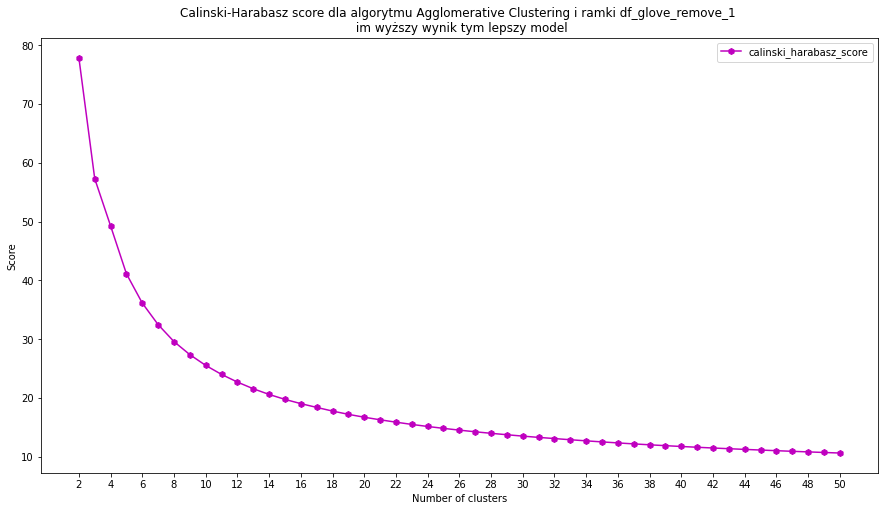

```python
ch_ranking_glove1_agg = score_plot(df_glove_remove_1, 50, AgglomerativeClustering, calinski_harabasz_score, "Calinski-Harabasz score dla algorytmu Agglomerative Clustering i ramki df_glove_remove_1 \n im wyższy wynik tym lepszy model", color = 'm')
```

#### df_glove_remove_2 - II sposób z GloVe

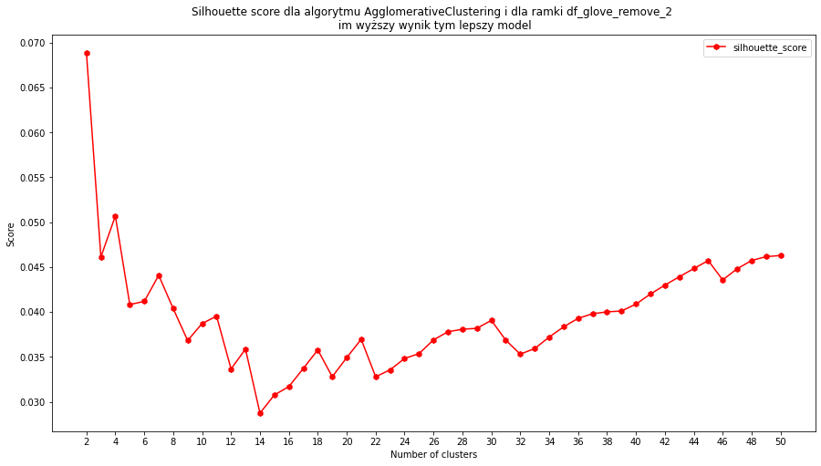

```python
silhouette_ranking_glove2_agg = score_plot(df_glove_remove_2, 50, AgglomerativeClustering, silhouette_score, "Silhouette score dla algorytmu AgglomerativeClustering i dla ramki df_glove_remove_2 \n im wyższy wynik tym lepszy model", color = 'r')
```

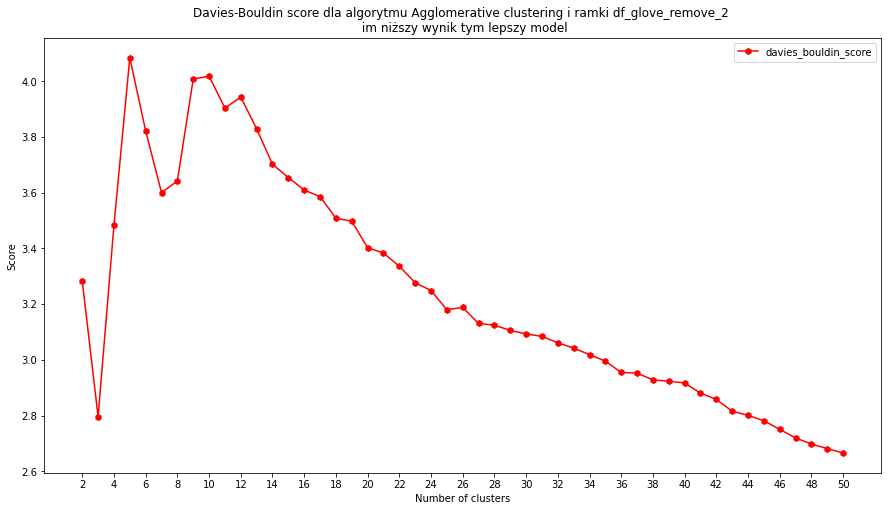

```python
db_ranking_glove2_agg = score_plot(df_glove_remove_2, 50, AgglomerativeClustering, davies_bouldin_score, "Davies-Bouldin score dla algorytmu Agglomerative clustering i ramki df_glove_remove_2 \n im niższy wynik tym lepszy model", color = 'r')
```

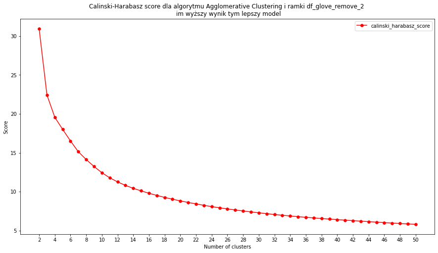

```python
ch_ranking_glove2_agg = score_plot(df_glove_remove_2, 50, AgglomerativeClustering, calinski_harabasz_score, "Calinski-Harabasz score dla algorytmu Agglomerative Clustering i ramki df_glove_remove_2 \n im wyższy wynik tym lepszy model", color = 'r')
```

Dalej wygląda na to, że najlepiej wypada podział na dwa skupiska (klastry). Trzeba będzie sprawdzić inaczej działające algorytmy klasteryzacji - może wtedy wyjdzie coś innego.